# Stucco Project

Jimmy Lozano

## Introduction

I will utilize KNN, GBM, and Random Forest models on Stucco dataset. I will compare the models based on the RMSE metric and choose the final model with the best metric. That final model will then be applied to the test dataset.

## Libraries and Data Collection

```r
rm(list=ls())
library(rstudioapi)
setwd(dirname(rstudioapi::getSourceEditorContext()$path))

library(MLmetrics)
library(randomForest)
library(caret)
library(dplyr)
library(gbm)
library(xgboost)
maindir = getwd()
data.dir = "/data/"       #data directory

stucco_train <- read.csv(paste(maindir,data.dir,"stucco.csv",sep=""),
                      stringsAsFactors = TRUE) # read in data

stucco_test <- read.csv(paste(maindir,data.dir,"stucco_test.csv",sep=""),
                      stringsAsFactors = TRUE) # read in data
```

## TrainControl object for KNN

Using slightly different parameters from class. Will utilize same train control object for consistency among each training model.

```r
set.seed(9279)

num_folds = 7
num_repeats = 5
train.control <- caret::trainControl(
  method = "repeatedcv",
  number = num_folds,
  repeats = num_repeats,
  savePredictions = TRUE,
  index = createMultiFolds(stucco_train$strength, k=num_folds, times=num_repeats) ,
  returnResamp = "all",
)
```

## Without categorical variables first

Note: I tried a KNN tuneGrid of 45 first but noticed they all get increasingly worse post 10 so I made the threshold 10 to have a more informative plot.

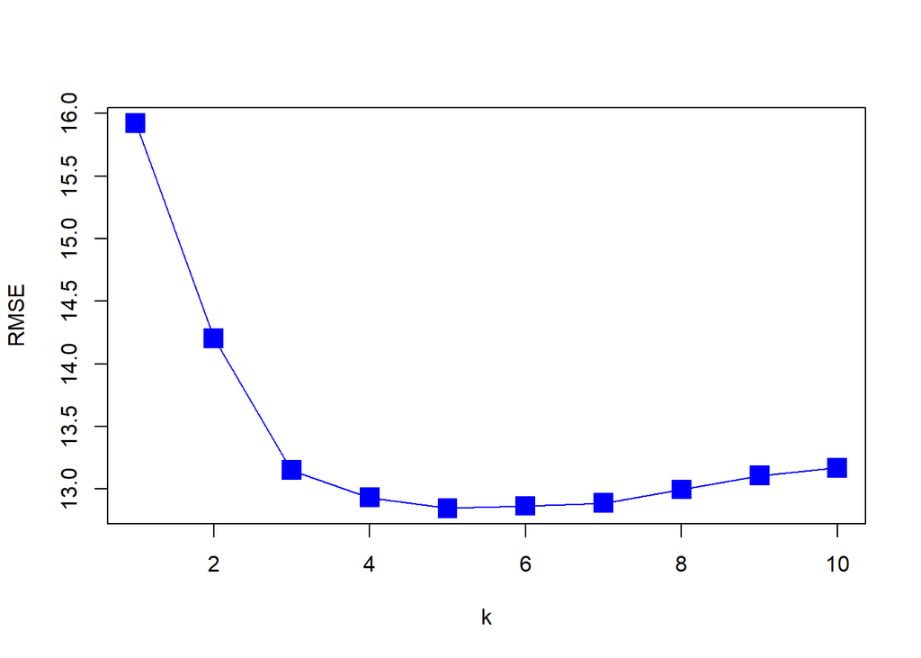

```r
## ----------------------------------------------------------------------------------------------------------------------------------
#knn with caret. make sure to include preProces
knn.cv <- caret::train(strength ~ .-method-mixing-region, data = stucco_train, method = "knn",
                       trControl = train.control, preProcess = c("range"),
                       tuneGrid = expand.grid(k = 1:10))

plot(knn.cv$results$k,knn.cv$results$RMSE,xlab="k",  ylab="RMSE",
     cex=2,pch=15,lwd=1, type="o", col = "blue")
```

```r
print(paste("The best K value with categorical is:", knn.cv$bestTune, "with RMSE:", min(knn.cv$results$RMSE)))
```

[output not shown]

## With Categorical

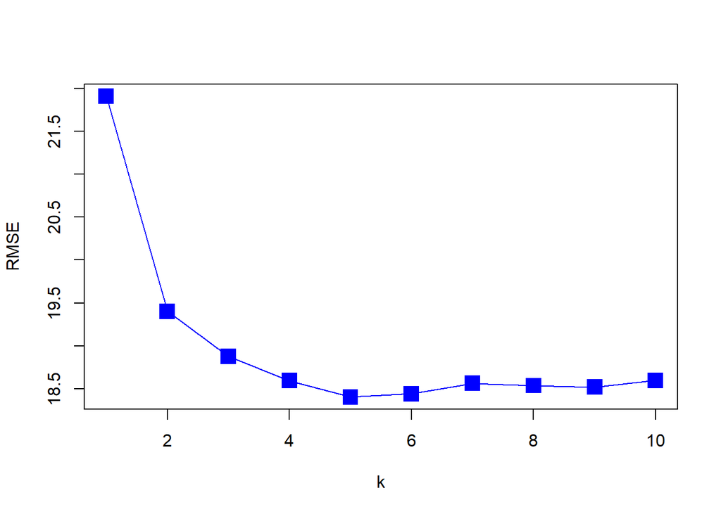

```r
#### Categorical
train.x <- model.matrix(strength~.,data=stucco_train)[,-1]

knn.cv_cat <- caret::train(x = train.x, y= stucco_train$strength, method = "knn",
                           trControl = train.control, preProcess = c("range"),
                           tuneGrid = expand.grid(k = 1:10))

plot(knn.cv_cat$results$k,knn.cv_cat$results$RMSE,xlab="k",  ylab="RMSE",
     cex=2,pch=15,lwd=1, type="o", col = "blue")
```

```r
knn.cv_cat$bestTune
```

```
##   k
## 5 5
```

```r
print(paste("The best K value with categorical is:", knn.cv_cat$bestTune, "with RMSE:", min(knn.cv_cat$results$RMSE)))
```

```
## [1] "The best K value with categorical is: 5 with RMSE: 18.4061685102219"
```

##GBM

```r
set.seed(102765)
#gbm  with caret. 4 differneet hyperparmaters
# create hyperparameter grid
hyper_grid <- expand.grid(
  n.trees = c(100, 500, 1000, 1500, 2000),
  shrinkage = c( .0001, 0.001, 0.01, 0.1),
  interaction.depth=c(1, 3, 5),
  n.minobsinnode = c(2, 8, 32)
)


gbm.cv_nocat <- caret::train(strength ~ .-method-mixing-region-age, data = stucco_train,
                      method="gbm",
                      distribution="gaussian",
                      verbose = FALSE,
                      trControl = train.control,
                      tuneGrid = hyper_grid )
gbm.cv_cat <- caret::train(strength ~ ., data = stucco_train,
                      method="gbm",
                      distribution="gaussian",
                      verbose = FALSE,
                      trControl = train.control,
                      tuneGrid = hyper_grid )

##Best hyperparamters
print(gbm.cv_nocat$bestTune)
```

```
##     n.trees interaction.depth shrinkage n.minobsinnode
## 125    2000                 5      0.01              2
```

```r
#final validation error
print(paste("GBM Best RMSE no categorical:" ,min(gbm.cv_nocat$results$RMSE)))
```

```
## [1] "GBM Best RMSE no categorical: 8.46726241522701"
```

```r
print(paste("GBM Best RMSE with categorical:" ,min(gbm.cv_cat$results$RMSE)))
```

```
## [1] "GBM Best RMSE with categorical: 6.18540018621238"
```

## Random Forest

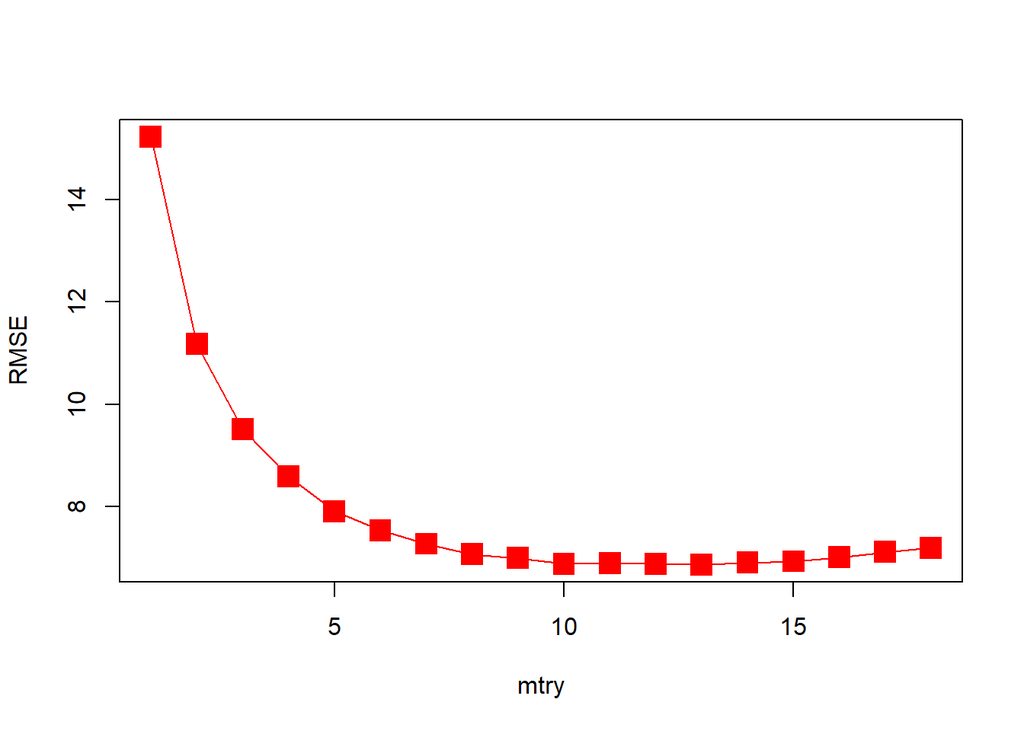

```r
mtry.vec = 1:(dim(stucco_train)[2]-1)
mtry.vec_nocat = 1:(dim(stucco_train)[2]-5)

rf.cv <- caret::train(strength ~ ., data = stucco_train,
                      method = "rf",
                      trControl = train.control,
                      ntree=350,
                      tuneGrid = expand.grid(.mtry=mtry.vec) )

rf.cv_nocat <- caret::train(strength ~ .-method-mixing-region-age, data = stucco_train,
                      method = "rf",
                      trControl = train.control,
                      ntree=350,
                      tuneGrid = expand.grid(.mtry=mtry.vec_nocat) )

plot(rf.cv$results$mtry,rf.cv$results$RMSE,xlab="mtry",  ylab="RMSE",
     cex=2,pch=15,lwd=1, type="o", col = "red")
```

```r
print(paste("Best mtry without categoricals:",rf.cv_nocat$bestTune, "with RMSE:",min(rf.cv_nocat$results$RMSE)))
```

```
## [1] "Best mtry without categoricals: 8 with RMSE: 8.79647615608321"
```

```r
print(paste("Best mtry with categoricals:",rf.cv$bestTune, "with RMSE:",min(rf.cv$results$RMSE)))
```

```
## [1] "Best mtry with categoricals: 13 with RMSE: 6.86456438304578"
```

## Winner?

I was struggling with choosing GBM since I knew it would be the more popular model as we discussed in class that it most often won Kaggle competitions. I did try different variables combinations such as just the additives, just the mixtures, or cement/ash/water, but they all gave RMSE values of 10+. The best combinations seemed to be between with and without categorical variables. Ultimately I decided to add more hyperparameters in order to best tune the model and give me something slightly more unique.

In conclusion, GBM with all variables was the ideal model for predicting the strength of stucco. Although it is worth noting that Random Forest had very similar RMSE values. I tried a few different seeds and sometimes saw the values become almost negligible. That being said, I will now apply the final GBM model to the test data set and save the predictions to a .csv file.

```r
set.seed(6207)

gbm.final <- gbm::gbm(strength ~ . , data = stucco_train,
                      n.trees=gbm.cv_nocat$bestTune[['n.trees']],
                      interaction.depth=gbm.cv_nocat$bestTune[['interaction.depth']],
                      shrinkage=gbm.cv_nocat$bestTune[['shrinkage']],
                      n.minobsinnode=gbm.cv_nocat$bestTune[['n.minobsinnode']],
                      distribution = "gaussian")

pred.strength <- predict(gbm.final,stucco_test)
```

```
## Using 2000 trees...
```

```r
pred.df <- data.frame(strength = pred.strength) #To get variable name in csv file
# Save the data frame to a CSV file
write.csv(pred.df, file = "predictions.csv", row.names = FALSE)
```